# 📊 APPLICATIVO INDICATORE

# Guida all’installazione e all’avvio dell’applicativo

Benvenuto!  
Questa guida ti accompagnerà passo dopo passo nell’installazione e nell’avvio dell’applicativo **Indicatore**.

## 🧩 1° Passo – Download del materiale

Scarica l’intera **cartella condivisa** e salvala in locale sul tuo computer.  
Assicurati che la struttura delle sottocartelle rimanga invariata.

## 🧠 2° Passo – Installazione di R

Segui le istruzioni contenute nel file **`Guida_Installazione_R.pdf`**.

> 💡 **Suggerimento:**  
> Anche se R è già installato, è consigliato aggiornarlo alla versione più recente, o comunque assicurarsi che sia installata **una versione pari o superiore alla 4.2.0**.

## ⚙️ 3° Passo – Installazione dei pacchetti necessari

1. Clicca sul file **`installazione_pacchetti.bat`**.  
   Si aprirà una finestra del **Prompt dei comandi** che scaricherà automaticamente tutte le librerie necessarie.
2. Potrebbe comparire un messaggio di sicurezza come questo — seleziona **“Esegui”**:

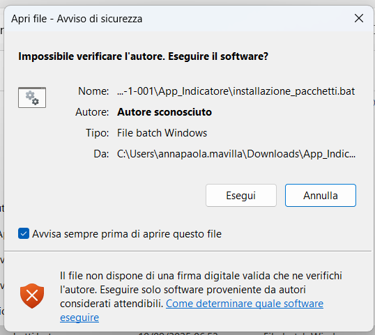

3. L’installazione dei pacchetti inizierà automaticamente.  
   Potrebbero essere necessari **fino a 10 minuti** per completare l’operazione.

   Attendi finché non compare il seguente messaggio:

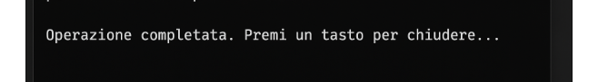

4. A questo punto, **premi un qualsiasi tasto** per chiudere la finestra.

## 💻 4° Passo – Avvio dell’applicativo

1. Clicca sul file **`Avvio_applicativo.bat`**.  
   Dopo pochi secondi, l’applicativo si aprirà automaticamente nel tuo **browser predefinito**.
2. Non chiudere **né la finestra nera del prompt dei comandi**, né **la finestra del browser** finché stai lavorando:  
   chiuderle comporta la perdita del lavoro in corso.

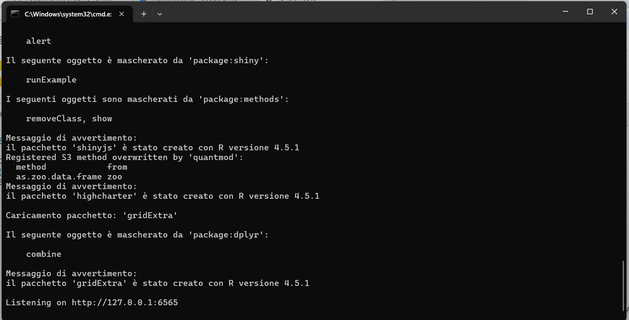

> ⚠️ **Importante:**  
> Leggi attentamente il manuale operativo prima di utilizzare l’applicativo.